# Lecture 9: Flexible Parametric Models and Model Checking

STA310 Survival Analysis · Collett Chapters 6 and 7

2026-10-06

## Today

1. Recap and motivation: limits of standard families
2. Piecewise exponential model
3. Royston–Parmar spline models
4. Other generalisations; choosing a model
5. Residuals for parametric models
6. Fitted vs Kaplan–Meier; influence; PH

**Learning goals**

You can

- explain when Weibull / log-normal are too rigid
- fit a piecewise exponential model as a Poisson GLM
- fit and compare spline models with `flexsurvspline()`
- check a parametric model with Cox–Snell residuals and by overlaying fitted curves on Kaplan–Meier

## Recap (Lecture 8)

- Parametric families: exponential, Weibull, log-logistic, log-normal
- Weibull and exponential: both PH and AFT; log-logistic: PO and AFT
- Fit with `survreg()` / `flexsurvreg()`, compare with AIC
- Gain: smooth $h(t)$, $S(t)$, absolute risks, extrapolation. Price: **the shape is assumed**

**Today’s questions**: what if the hazard shape is not in any standard family, and how do we *know* a parametric model fits?

# Beyond the standard families

## Hazard shapes of the standard families

| Family | Hazard shape |
| --- | --- |
| Exponential | constant |
| Weibull | monotone (increasing or decreasing) |
| Log-logistic | decreasing, or one hump (as in Lecture 8) |
| Log-normal | one hump, then decreases to 0 |

Real hazards can be

- **hump-shaped** with a peak that is not tied to the tail behaviour (recurrence after surgery)
- **bathtub-shaped** (early mortality, plateau, ageing)
- **complex**: several changes, e.g. after transplantation

## A medical example where the hazard peaks

Recurrence-free survival in 686 breast cancer patients (time in days, 299 events). Recurrence hazard after surgery is known to rise and then fall.

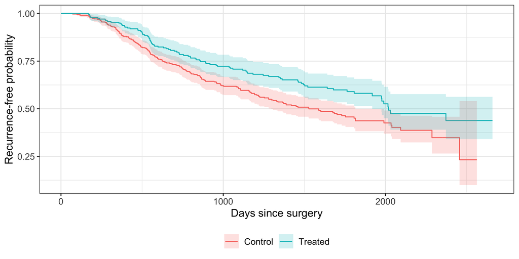

```r
survfit2(Surv(time, status) ~ treat, data = bc) |>
  ggsurvfit() + add_confidence_interval() +
  labs(x = "Days since surgery", y = "Recurrence-free probability")
```

The KM curve is steepest in the middle of follow-up: a monotone Weibull hazard cannot reproduce that.

# Piecewise exponential model

## Idea

Cut the time axis at $a_0 = 0 < a_1 < \dots < a_J$. Assume a **constant hazard in each interval**:

$$h(t \mid x) = \lambda_j \exp(\beta^\top x), \qquad a_{j-1} \le t < a_j$$

- Baseline hazard is a step function with $J$ parameters
- With $J = 1$: exponential model. With many intervals: close to a non-parametric baseline
- Covariates enter as proportional hazards, as in Cox
- Cut points are chosen by the analyst (e.g. quantiles of event times)

## Fitting as a Poisson regression

Within each interval the likelihood contribution of a patient is that of a Poisson variable:

- $d_{ij}$ = event indicator in interval $j$ (0/1)
- $y_{ij}$ = time at risk in interval $j$
- $d_{ij} \sim \text{Poisson}(\mu_{ij})$ with $\log \mu_{ij} = \log y_{ij} + \log\lambda_j + \beta^\top x_i$

Recipe:

1. **Split** each patient’s follow-up into intervals (`survSplit()`)
2. Compute time at risk per row
3. `glm(event ~ interval + covariates + offset(log(time at risk)), family = poisson)`

## Step 1: split the data

```r
cuts <- c(500, 1000, 1500, 2000)
bc_split <- survSplit(Surv(time, status) ~ treat + nodes, data = bc,
                      cut = cuts, episode = "interval", start = "tstart", end = "tstop")
bc_split$risktime <- bc_split$tstop - bc_split$tstart
bc_split$interval <- factor(bc_split$interval)
bc_split |> filter(row_number() %in% 1:6)
```

```
    treat nodes tstart tstop status interval risktime
1 Control     3      0   500      0        1      500
2 Control     3    500  1000      0        2      500
3 Control     3   1000  1500      0        3      500
4 Control     3   1500  1814      1        4      314
5 Treated     7      0   500      0        1      500
6 Treated     7    500  1000      0        2      500
```

686 patients became 1879 rows. A patient who recurs after the last cut (e.g. at day 2456) has one row per interval, with `status = 1` only in the last.

## Step 2: Poisson GLM with offset

```r
pe <- glm(status ~ interval + treat + nodes + offset(log(risktime)),
          family = poisson, data = bc_split)
broom::tidy(pe, exponentiate = TRUE, conf.int = TRUE) |>
  mutate(across(where(is.numeric), \(x) round(x, 4)))
```

```
# A tibble: 7 × 7
  term         estimate std.error statistic p.value conf.low conf.high
  <chr>           <dbl>     <dbl>     <dbl>   <dbl>    <dbl>     <dbl>
1 (Intercept)    0.0002    0.120    -69.0    0        0.0002    0.0003
2 interval2      1.79      0.137      4.25   0        1.37      2.34
3 interval3      1.29      0.175      1.47   0.141    0.912     1.82
4 interval4      1.25      0.229      0.970  0.332    0.780     1.92
5 interval5      2.29      0.350      2.36   0.0183   1.07      4.29
6 treatTreated   0.700     0.125     -2.85   0.0043   0.546     0.891
7 nodes          1.06      0.0067     8.67   0        1.04      1.07
```

## Bridge to the Cox model

```r
cox <- coxph(Surv(time, status) ~ treat + nodes, data = bc)
tibble(term = c("treat", "nodes"),
       Cox = exp(coef(cox)),
       PiecewiseExp = exp(coef(pe)[c("treatTreated", "nodes")]))
```

```
# A tibble: 2 × 3
  term    Cox PiecewiseExp
  <chr> <dbl>        <dbl>
1 treat 0.700        0.700
2 nodes 1.06         1.06
```

- The estimated HRs are very close: the Cox model is the **limit** of the piecewise exponential model when the intervals become so fine that each contains one event time
- The Cox partial likelihood = profile likelihood over a free step-function baseline
- Piecewise exponential gives a baseline hazard **estimate** and allows non-PH by interval-by-covariate interactions, and also time-dependent covariates (Lecture 10) and time-varying effects (Lecture 11)

**Warning**

Cut points should not be chosen by looking at which cuts give the “best” treatment effect. Keep enough events per interval (roughly 10-20 as a rough guide).

## Piecewise exponential baseline hazard

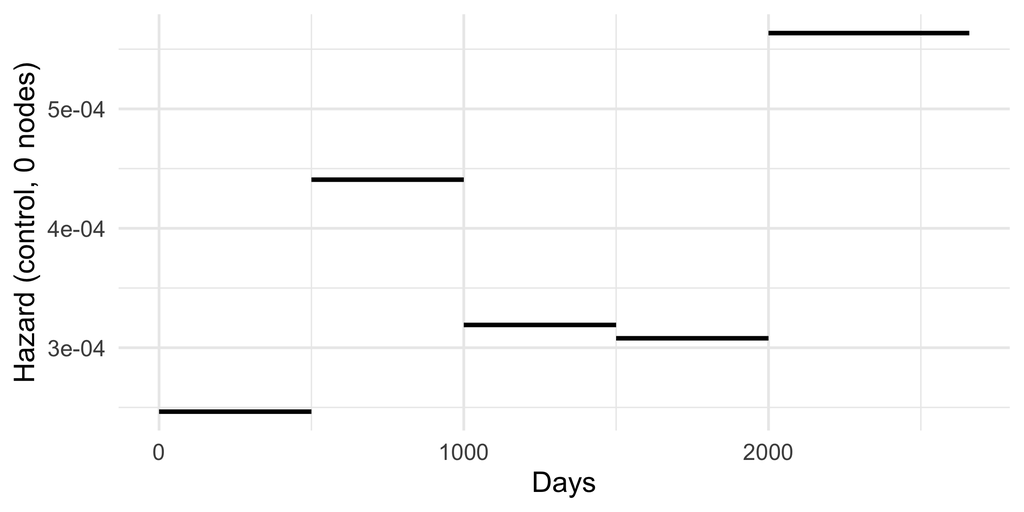

```r
base <- tibble(tstart = c(0, cuts), tstop = c(cuts, max(bc$time)),
               rate = c(exp(coef(pe)["(Intercept)"]),
                        exp(coef(pe)["(Intercept)"] + coef(pe)[paste0("interval", 2:5)])))
ggplot(base, aes(x = tstart, xend = tstop, y = rate, yend = rate)) +
  geom_segment(linewidth = 1.2) +
  labs(x = "Days", y = "Hazard (control, 0 nodes)")
```

The step-function hazard is lowest in the first interval, highest after day 2000 and dips between 1000 and 2000: it is clearly not monotone (and the last interval is based on few patients), but it is not a clean hump either. Smoother alternatives follow.

# Royston–Parmar spline models

## Idea

For the Weibull model: $\log H(t) = \log\lambda + \gamma \log t$ (Lecture 8), a **straight line in $\log t$**.

Royston–Parmar: replace the straight line by a **natural (restricted) cubic spline** in $\log t$:

$$\log H(t \mid x) = s(\log t;\, \mathbf{s}, \mathbf{k}) + \beta^\top x$$

- $k$ interior knots (placed at quantiles of the log uncensored event times), plus 2 boundary knots
- $k = 0$: $s = s_0 + s_1 \log t$, the **Weibull** model
- Linear beyond the boundary knots (stable tails)
- Covariate effects: $\beta$ is a log hazard ratio, as in a PH model. The linear predictor is written $\eta = \beta^\top x$ consistently (Lectures 8-9); the spline coefficients $s_0, s_1, \dots$ avoid a clash with the Weibull shape $\gamma$

Since $h(t) = \frac{d}{dt}H(t)$ is derived from the fitted $H$, the model gives $S(t)$ and $h(t)$ in closed form.

## Three scales

The same spline idea on different transformations of $S(t)$:

| Scale | Model for | $\beta$ is a… |
| --- | --- | --- |
| `hazard` (PH) | $\log H(t) = \log\{-\log S(t)\}$ | log hazard ratio |
| `odds` (PO) | $\log\{(1-S)/S\}$ | log odds ratio of surviving |
| `normal` (probit) | $\Phi^{-1}(1 - S(t))$ | probit-scale shift |

- $k = 0$ gives Weibull (hazard), log-logistic (odds), log-normal (normal)
- Choose scale and $k$ by AIC/BIC; the choice matters mostly in the tails
- In `flexsurvspline()`: argument `scale = "hazard"` (default), `"odds"`, `"normal"`

## First example: hypernephroma

36 patients, survival by nephrectomy (`nephrectomy` No/Yes); time units as in the data.

```r
library(flexsurv)
sp_h <- lapply(0:2, \(k) flexsurvspline(Surv(time, status) ~ nephrectomy, data = hyper, k = k))
tibble(k = 0:2, AIC = map_dbl(sp_h, AIC), BIC = map_dbl(sp_h, BIC))
```

```
# A tibble: 3 × 3
      k   AIC   BIC
  <int> <dbl> <dbl>
1     0  298.  303.
2     1  296.  303.
3     2  295.  303.
```

With only 36 patients and 32 events a flexible model has little to work with: AIC changes by 3 between $k = 0$ and $k = 2$, and BIC by 0.2 (positive = $k = 1$ lower) between $k = 0$ and $k = 1$.

## Hypernephroma: the fitted model

```r
sp_h[[2]]
```

```
Call:
flexsurvspline(formula = Surv(time, status) ~ nephrectomy, data = hyper,
    k = k)

Estimates:
                data mean  est       L95%      U95%      se        exp(est)
gamma0                NA   -5.13483  -7.65126  -2.61839   1.28392        NA
gamma1                NA    2.03033   1.08910   2.97156   0.48023        NA
gamma2                NA    0.16092  -0.00861   0.33045   0.08650        NA
nephrectomyYes   0.80556   -1.75519  -2.74702  -0.76336   0.50604   0.17287
                L95%      U95%
gamma0                NA        NA
gamma1                NA        NA
gamma2                NA        NA
nephrectomyYes   0.06412   0.46610

N = 36,  Events: 32,  Censored: 4
Total time at risk: 1340
Log-likelihood = -144.2456, df = 4
AIC = 296.4911
```

The `nephrectomy` row is the log hazard ratio on the PH scale: HR = 0.17 (95% CI 0.06 to 0.47). The estimate is unadjusted (no age term) and based on few patients.

## Back to the breast cancer data: choose $k$

```r
fits <- lapply(0:4, \(k) flexsurvspline(Surv(time, status) ~ treat + nodes, data = bc, k = k))
wb <- flexsurvreg(Surv(time, status) ~ treat + nodes, data = bc, dist = "weibullPH")
tibble(model = c("Weibull", paste0("spline k=", 1:4)),
       logLik = c(logLik(wb), map_dbl(fits[2:5], \(f) as.numeric(logLik(f)))),
       df = c(wb$npars, map_dbl(fits[2:5], \(f) f$npars)),
       AIC = c(AIC(wb), map_dbl(fits[2:5], AIC)),
       BIC = c(BIC(wb), map_dbl(fits[2:5], BIC)))
```

```
# A tibble: 5 × 5
  model      logLik    df   AIC   BIC
  <chr>       <dbl> <dbl> <dbl> <dbl>
1 Weibull    -2604.     4 5216. 5234.
2 spline k=1 -2585.     5 5179. 5202.
3 spline k=2 -2583.     6 5178. 5205.
4 spline k=3 -2582.     7 5178. 5209.
5 spline k=4 -2582.     8 5180. 5216.
```

- The spline with $k = 0$ reproduces the Weibull fit (AIC 5216.2 = 5216.2)
- One knot improves AIC by 37.2; see the table for further knots. AIC picks $k =$ 3, BIC $k =$ 1
- Pragmatic choice: a small $k$ whose plots look sensible, with differences in AIC below about 2 often treated as ties

## Choosing the number of knots: advice

- Start with $k = 1$ to $3$; more rarely needed (as rough guidance, fewer than about 20 events per knot is probably too few)
- Compare AIC (prefers fit) and BIC (prefers parsimony); check that *plots* of $h(t)$ do not change much between neighbouring $k$
- Knot positions: default quantiles of uncensored $\log t$; changing them has usually small impact
- Too many knots give a **wiggly hazard** and unstable tails
- Spline fit outside the data range: linear in $\log H$, i.e. a Weibull-like extrapolation, **not guaranteed to be sensible**

## Fitted hazard: Weibull vs spline

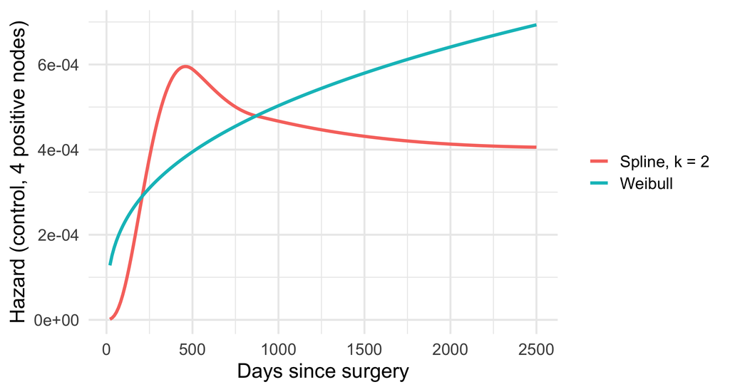

```r
nd <- data.frame(treat = factor("Control", levels = levels(bc$treat)), nodes = 4)
tt <- seq(20, 2500, length.out = 200)
haz <- bind_rows(
  summary(wb, newdata = nd, type = "hazard", t = tt, tidy = TRUE) |> mutate(model = "Weibull"),
  summary(fits[[3]], newdata = nd, type = "hazard", t = tt, tidy = TRUE) |> mutate(model = "Spline, k = 2"))
ggplot(haz, aes(time, est, colour = model)) + geom_line(linewidth = 1.2) +
  labs(x = "Days since surgery", y = "Hazard (control, 4 positive nodes)", colour = NULL)
```

The Weibull (PH) hazard is monotone; the spline model shows rise to a peak and subsequent decline. This is a clinically plausible recurrence pattern, the Weibull misses it.

## Fitted survival: spline vs Weibull, by treatment

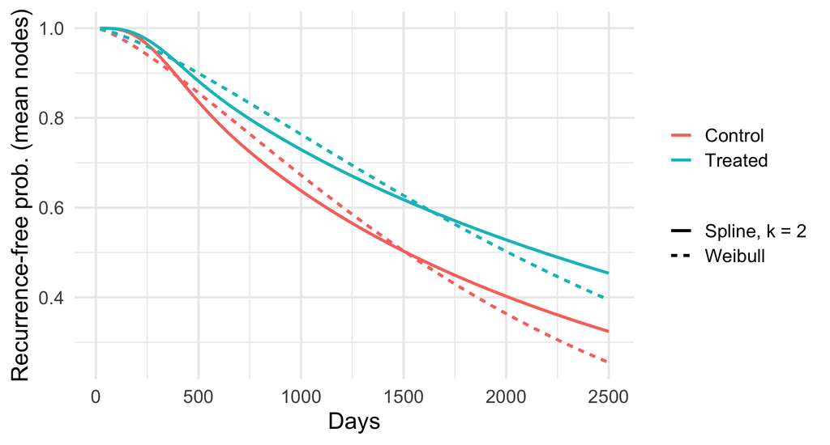

```r
nd2 <- data.frame(treat = levels(bc$treat), nodes = mean(bc$nodes)) |>
  mutate(treat = factor(treat, levels = levels(bc$treat)))
sv <- bind_rows(
  summary(wb, newdata = nd2, type = "survival", t = tt, tidy = TRUE) |> mutate(model = "Weibull"),
  summary(fits[[3]], newdata = nd2, type = "survival", t = tt, tidy = TRUE) |> mutate(model = "Spline, k = 2"))
ggplot(sv, aes(time, est, colour = treat, linetype = model)) + geom_line(linewidth = 1) +
  labs(x = "Days", y = "Recurrence-free prob. (mean nodes)", colour = NULL, linetype = NULL)
```

## Reading the treatment effect

```r
tibble(model = c("Weibull", "Spline k=2"),
       HR = c(exp(coef(wb)["treatTreated"]), exp(coef(fits[[3]])["treatTreated"])),
       lower = c(exp(confint(wb)["treatTreated", 1]), exp(confint(fits[[3]])["treatTreated", 1])),
       upper = c(exp(confint(wb)["treatTreated", 2]), exp(confint(fits[[3]])["treatTreated", 2])))
```

```
# A tibble: 2 × 4
  model         HR lower upper
  <chr>      <dbl> <dbl> <dbl>
1 Weibull    0.681 0.533 0.870
2 Spline k=2 0.701 0.549 0.896
```

For `treat`, the HR can be compared across baselines (Weibull PH 0.68 vs 0.7; compare Cox: 0.7). The flexible baseline matters for **absolute risk and hazard shape**, less for relative effects. Note that the HR is only interpretable if the PH assumption is reasonable.

## Non-proportional effects in the spline model

Allow the treatment effect to vary with time through `anc`: the spline slope ($s_1$, called `gamma1` in `flexsurv`) depends on `treat`.

```r
fit_nph <- flexsurvspline(Surv(time, status) ~ treat + nodes, data = bc, k = 2,
                          anc = list(gamma1 = ~ treat))
tibble(model = c("PH, k=2", "treat x spline slope"),
       df = c(fits[[3]]$npars, fit_nph$npars), AIC = c(AIC(fits[[3]]), AIC(fit_nph)),
       LRT_p = c(NA, pchisq(2 * (logLik(fit_nph) - logLik(fits[[3]])), 1, lower.tail = FALSE)))
```

```
# A tibble: 2 × 4
  model                   df   AIC  LRT_p
  <chr>                <int> <dbl>  <dbl>
1 PH, k=2                  6 5178. NA
2 treat x spline slope     7 5180.  0.594
```

A likelihood-ratio test for one extra parameter gives $p$ = 0.59: this checks PH for treatment only, with limited power.

## PO and probit scales

```r
scales <- c("hazard", "odds", "normal")
sc <- lapply(scales, \(s) flexsurvspline(Surv(time, status) ~ treat + nodes, data = bc, k = 2, scale = s))
tibble(scale = scales, AIC = map_dbl(sc, AIC), BIC = map_dbl(sc, BIC))
```

```
# A tibble: 3 × 3
  scale    AIC   BIC
  <chr>  <dbl> <dbl>
1 hazard 5178. 5205.
2 odds   5169. 5197.
3 normal 5170. 5197.
```

## Other generalisations (one slide)

- **Generalised gamma**: three parameters; contains exponential, Weibull, log-normal as special cases. `flexsurvreg(..., dist = "gengamma")`. Allows hump and bathtub shapes
- **Splines on the hazard** (Collett §6.3): $\log h(t)$ modelled with splines; harder to get $S(t)$ (numerical integration)
- **Time-dependent effects** via spline interactions (as above) or in the `rstpm2` package (name only)
- **Mixture cure and other models** are beyond this course

## Choosing between Cox, Weibull and flexible parametric

| Situation | Cox | Weibull / standard | Flexible parametric (spline) |
| --- | --- | --- | --- |
| Question: relative effect (HR) only | **good default** | fine if the model fits | fine |
| Small sample (roughly $<$ 50 events) | good | **good**, parsimonious | risk of overfitting |
| Absolute risk / $S(t)$ at covariate values | needs baseline estimate (step function) | smooth, simple | **smooth and flexible** |
| Hazard shape of interest | no | only monotone | **yes** |
| Extrapolation beyond follow-up | no | yes, but strong assumption | yes, but linear in $\log t$ tail |
| Non-PH, time-varying effects | extensions needed | AFT alternative | interactions with spline |

# Model checking (Chapter 7)

## Why check?

A parametric model gives more than a Cox model, so it can be more wrong.

- The **distribution** (e.g. Weibull) may not hold
- The **linear predictor** may be misspecified (transformations, interactions)
- Individual patients may be **outliers or influential**

Two types of tools: **residuals** (per patient) and **fitted vs non-parametric curves** (per group). Everything here has a Cox analogue (Lectures 6-7), but we now use the fitted parametric model.

## Example: ovarian cancer

The ovarian cancer data from Lecture 8 (26 women; `treat` Single/Combined, `rdisease` Incomplete/Complete, `perf` Good/Poor). The Weibull AFT model is the one from Lecture 8; it is refitted here only to obtain residuals.

```r
wb_ov <- survreg(Surv(time, status) ~ treat + age + rdisease + perf, data = ovar, dist = "weibull")
```

With 26 patients and 12 events, power for any check is low.

## Cox–Snell residuals: the idea

If $T_i$ has survivor function $S_i(t)$ then $S_i(T_i) \sim U(0, 1)$, so

$$r_i = \hat H_i(t_i) = -\log \hat S_i(t_i) \sim \text{Exp}(1)$$

If the model is right, $\{r_i\}$ behave like a **censored sample from the unit exponential**. Censored observations give censored residuals.

For the Weibull AFT model $\log T = \eta_i + \sigma\varepsilon$:

$$r_i = \exp\left\{\frac{\log t_i - \hat\eta_i}{\hat\sigma}\right\}$$

**Check**: compute the Kaplan–Meier / Nelson–Aalen estimate of $H$ for $(r_i, \delta_i)$. Plot $\hat H_{r}(r)$ against $r$: it should lie close to the line $y = x$.

## Cox–Snell residuals in R

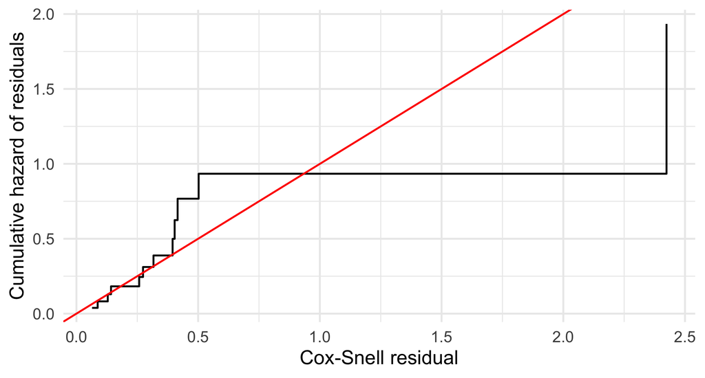

```r
eta_hat <- predict(wb_ov, type = "lp")
ovar$cs <- exp((log(ovar$time) - eta_hat) / wb_ov$scale)
na <- survfit(Surv(cs, status) ~ 1, data = ovar)
ggplot(tibble(r = na$time, H = cumsum(na$n.event / na$n.risk)),
       aes(r, H)) +
  geom_step() + geom_abline(colour = "red") +
  labs(x = "Cox-Snell residual", y = "Cumulative hazard of residuals")
```

## Cox–Snell residuals: cautions

**Warning**

- Collett: Cox–Snell residuals are **good for overall fit of the distribution**, poor for detecting a missing covariate or functional form
- Censored residuals are not “observed”, so large residuals with censoring are not outliers
- Deviations in the tail where few are at risk are expected: do not over-read
- Adding variables that were *fitted* to the data makes the plot look better by construction

Graphical check of the family: the Weibull plot from Lecture 8.

## Standardised residuals

For the AFT form $\log T_i = \eta_i + \sigma\varepsilon_i$:

$$r_{Si} = \frac{\log t_i - \hat\eta_i}{\hat\sigma}$$

These estimate the error terms $\varepsilon_i$, which have a **known distribution** (extreme value for Weibull, logistic for log-logistic, normal for log-normal). The Cox–Snell residual is $\exp(r_{Si})$ for Weibull. Here $\hat\sigma$ is `survreg`’s `scale`, linked to the Weibull shape of Lecture 8 by $\gamma = 1/\sigma$.

Check: the Kaplan–Meier estimate of the survivor function of $r_{Si}$ against the theoretical one. For log-normal models this gives a **normal QQ-plot**-type check.

## Martingale and deviance residuals

- **Martingale residual**: $r_{Mi} = \delta_i - r_i$. Ranges in $(-\infty, 1]$, skewed, mean 0. Positive: died earlier than the model expects
- **Deviance residual**: a transform to be more symmetric around 0,
  $$r_{Di} = \text{sign}(r_{Mi})\sqrt{-2\{r_{Mi} + \delta_i \log(\delta_i - r_{Mi})\}}$$

Use: **plot against $\hat\eta_i$ or covariates** (e.g. age) to find outliers or non-linearity; approximately symmetric around zero if the model fits. Expect larger spread with high censoring.

## Martingale and deviance residuals in R

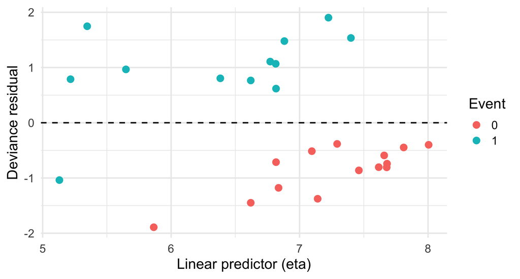

```r
ovar$mart <- ovar$status - ovar$cs
ovar$dev <- sign(ovar$mart) * sqrt(-2 * (ovar$mart + ifelse(ovar$status == 1, ovar$status * log(ovar$status - ovar$mart), 0)))
ovar$eta <- eta_hat
ggplot(ovar, aes(eta, dev, colour = factor(status))) + geom_point(size = 3) +
  geom_hline(yintercept = 0, linetype = 2) +
  labs(x = "Linear predictor (eta)", y = "Deviance residual", colour = "Event")
```

Censored patients have negative residuals (cannot be positive). Look for **points with $|r_D| > 2$**: here 0 patient(s). Check by eye for any trend with the linear predictor.

## Comparing observed and fitted survival (Collett §7.3)

The most intuitive check: overlay the **fitted parametric $S(t)$** on the **Kaplan–Meier** curve, for each group.

1. Fit the model, predict $\hat S(t)$ for a typical covariate profile of the group
2. Plot together with KM
3. Look for systematic gaps, especially where the KM curve is well-estimated (many at risk)

For models with several covariates: compare with **group-average fitted survival** (average $\hat S(t \mid x_i)$ over the patients in the group).

## Fitted vs KM, breast cancer by treatment

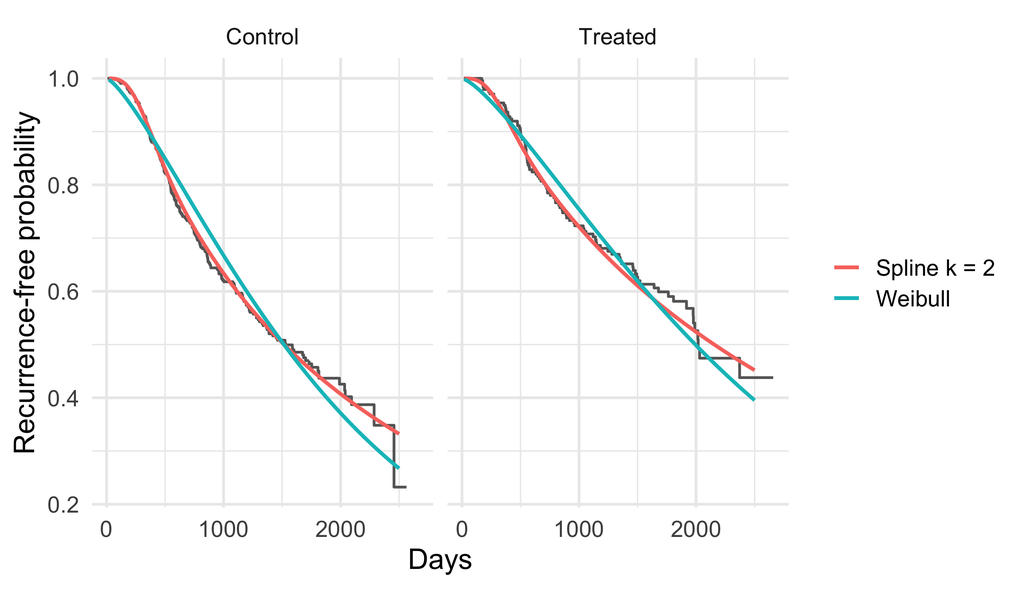

```r
km <- survfit(Surv(time, status) ~ treat, data = bc)
kmd <- tibble(time = km$time, surv = km$surv, treat = rep(levels(bc$treat), km$strata))
avg_surv <- function(fit, label) {
  ts <- seq(20, 2500, length.out = 80)
  map_dfr(levels(bc$treat), \(g) {
    nd <- bc |> filter(treat == g)
    s <- summary(fit, newdata = nd, type = "survival", t = ts, tidy = TRUE, B = 0)
    s |> group_by(time) |> summarise(surv = mean(est), .groups = "drop") |> mutate(treat = g, model = label)
  })
}
fitted_all <- bind_rows(avg_surv(wb, "Weibull"), avg_surv(fits[[3]], "Spline k = 2"))
ggplot() + geom_step(data = kmd, aes(time, surv), colour = "grey40") +
  geom_line(data = fitted_all, aes(time, surv, colour = model), linewidth = 1) +
  facet_wrap(~ treat) + labs(x = "Days", y = "Recurrence-free probability", colour = NULL)
```

Grey: Kaplan–Meier. Both models are close overall; the spline follows the early shape better. The Weibull systematically deviates when the hazard is non-monotone.

## Influential observations (Collett §7.4)

- **Influence**: how much would $\hat\beta$ change if patient $i$ were removed?
- Approximation without refitting: **score / dfbeta residuals**, $\Delta_i\hat\beta \approx$ change in $\hat\beta$
- `residuals(fit, type = "dfbeta")` is available for `survreg`

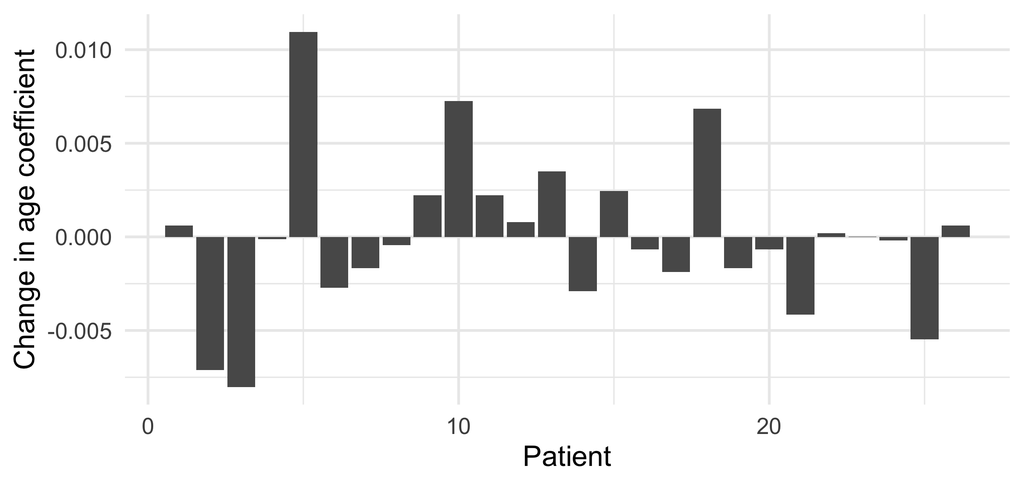

```r
db <- residuals(wb_ov, type = "dfbeta")
colnames(db) <- c(names(coef(wb_ov)), "logscale")
tibble(id = ovar$patient, age = db[, "age"]) |>
  ggplot(aes(id, age)) + geom_col() +
  labs(x = "Patient", y = "Change in age coefficient")
```

Large bars flag patients to re-analyse without. Remember that influence is in units of the parameter: compare with its standard error (0.019).

## PH assumption in the parametric framework

- Log-log plots and Weibull PH/AFT equivalence: see Lecture 8
- New here: test PH with an **extra term** $\text{group} \times \log t$ (LRT, Collett §7.5)
- In spline models, interaction of covariate and spline terms (as seen above) tests PH
- **Log-logistic**: PO, not PH; PH and AFT are different assumptions for most families
- If PH fails: stratify, time-dependent covariates (Lecture 10), non-PH / time-varying effects (Lecture 11), use AFT, or the flexible model

## Quiz

1. For a correct model, Cox–Snell residuals should look like…?
2. Which spline model with $k = 0$ equals the Weibull?
3. Why can a Poisson GLM give the same HR as Cox?
4. Which is likely better for a small trial of 30 events: Weibull or $k = 3$ spline?
1. A censored sample from Exp(1): $\hat H(r) \approx r$. 2. PH scale. 3. Piecewise exponential with fine cuts approximates the Cox partial likelihood. 4. Weibull: spline parameters are not stably estimated with so few events.

## Exercise (in class, 15 minutes)

Use `survival::lung` (n = 228, `status` 1/2 = censored/dead, time in days) or the breast cancer data.

1. Fit Weibull and `flexsurvspline()` with $k$ = 1, 2, 3 for `Surv(time, status) ~ sex`. Compare AIC and BIC.
2. Plot the fitted hazards for men. Is the shape monotone?
3. Compute Cox–Snell residuals for your Weibull model and make the plot of $\hat H(r)$ vs $r$.
4. Overlay the fitted survival on KM by sex. What do you conclude?

```r
lung2 <- survival::lung |> mutate(status = status - 1)
flexsurv::flexsurvspline(Surv(time, status) ~ sex, data = lung2, k = 1)
```

## Take-home messages

- Standard families force a hazard shape; **piecewise exponential** and **Royston–Parmar splines** relax this
- The piecewise exponential model is a **Poisson GLM** on split data; it bridges parametric and Cox
- Spline models on $\log H(t)$ with $k$ knots: $k = 0$ is Weibull; choose $k$ with AIC/BIC **and** plots
- Relative effects are often robust to baseline shape; absolute risks and hazard shapes are not
- Check models with **Cox–Snell residuals** ($\approx$ censored Exp(1)), deviance residuals, and **fitted vs KM**
- Check PH inside the parametric model and watch influential patients

**Next lecture** (Lecture 10): time-dependent covariates (Collett, Chapter 8); time-varying effects and non-PH follow in Lecture 11

**Reading**: Collett, Chapter 6 (§6.1, 6.2.3, 6.4) and Chapter 7 (§7.1-7.3, 7.5); skip the rest.